# Manipulação e Visualização de Dados com Tidyverse

# Manipulação e Visualização de Dados com Tidyverse

## Introdução

Manipulação e visualização de dados (MVD) são atividades essenciais para qualquer cientista de dados. Seja para análise exploratória, modelagem, Business Intelligence (BI), construção de gráficos, ou criação de modelos de machine learning, essas tarefas são comuns a todos que trabalham com dados.

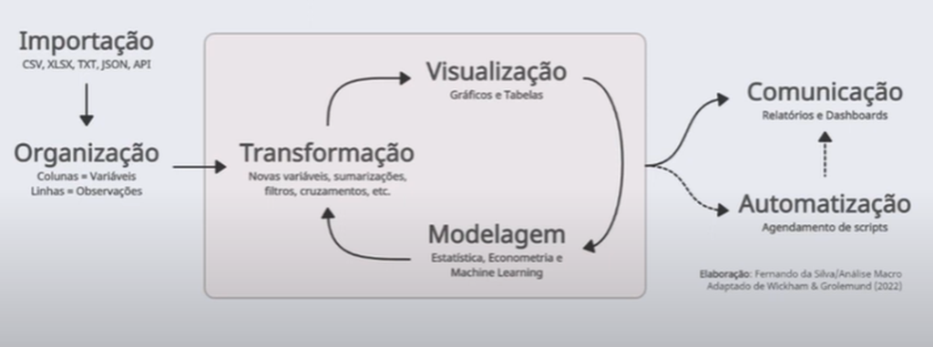

*Etapas do tratamento e análises de dados*

Realizar o MVD de maneira eficiente é crucial para o sucesso nas etapas subsequentes de um projeto de ciência de dados, como:

- *Entendimento*correto dos dados
- *Limpeza e conciliação*de dados de diferentes fontes
- **Engenharia de características**
- **Especificação e validação de modelos**
- **Interpretação e comunicação dos resultados**

## Vantagens do Uso de Linguagens de Programação

As linguagens de programação, como o R, oferecem vantagens significativas em relação a softwares com interfaces gráficas:

- **Reprodutibilidade**
- **Extensibilidade**
- **Escalabilidade**
- **Integração**

A maioria das empresas já reconhece a importância dessas vantagens. Em projetos de ciência de dados, **60% do tempo** é gasto em **limpeza e organização de dados**, com **20% do tempo** adicional gasto em **coleta de dados**. Isso demonstra a importância de dominar boas práticas e ferramentas para manipulação eficiente de dados.

## O Framework do Tidyverse

O Tidyverse é uma coleção de pacotes R que trabalham em harmonia, oferecendo uma gramática e filosofia unificada para a manipulação e visualização de dados. Vamos explorar os principais pacotes do Tidyverse e entender como eles podem facilitar o trabalho com dados.

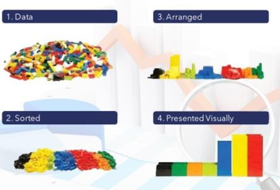

*Processo de Transformação de Dados*

### Instalação do Tidyverse

```r
# Carregando o Tidyverse
library(tidyverse)
```

### Pacotes do Tidyverse

```r
library(tidyverse)
tidyverse_packages()
```

[output not shown]

[figure not shown]

*Pacotes do Tidyverse*

### O Tibble

O `tibble` é uma reimplementação do `data.frame`, oferecendo uma interface mais intuitiva e eficiente para manipulação de dados tabulares.

#### Exemplo de Tibble

Vamos criar um `tibble` a partir de dados nativos do R:

| Sepal.Length | Sepal.Width | Petal.Length | Petal.Width | Species |
| --- | --- | --- | --- | --- |
| 5.1 | 3.5 | 1.4 | 0.2 | setosa |
| 4.9 | 3.0 | 1.4 | 0.2 | setosa |
| 4.7 | 3.2 | 1.3 | 0.2 | setosa |
| 4.6 | 3.1 | 1.5 | 0.2 | setosa |
| 5.0 | 3.6 | 1.4 | 0.2 | setosa |
| 5.4 | 3.9 | 1.7 | 0.4 | setosa |
| 4.6 | 3.4 | 1.4 | 0.3 | setosa |
| 5.0 | 3.4 | 1.5 | 0.2 | setosa |
| 4.4 | 2.9 | 1.4 | 0.2 | setosa |
| 4.9 | 3.1 | 1.5 | 0.1 | setosa |

[output cut: 140 more lines]

### O Readr

O `readr` é um pacote utilizado para leitura e escrita de arquivos de texto pleno, como `.txt` e `.csv`. Ele é otimizado para ser mais rápido e eficiente, permitindo ler arquivos maiores e armazenar mais dados na memória.

#### Funções de Leitura e Escrita no Readr

O `readr` também permite o “parsing” automático de colunas, identificando e convertendo campos de data, hora, e duração durante a leitura.

### O Tidyr

O `tidyr` é um pacote voltado para a arrumação de dados, permitindo transformar dados desorganizados em um formato tidy (organizado), onde:

- Cada variável é uma coluna.
- Cada observação é uma linha.
- Cada valor é uma célula.

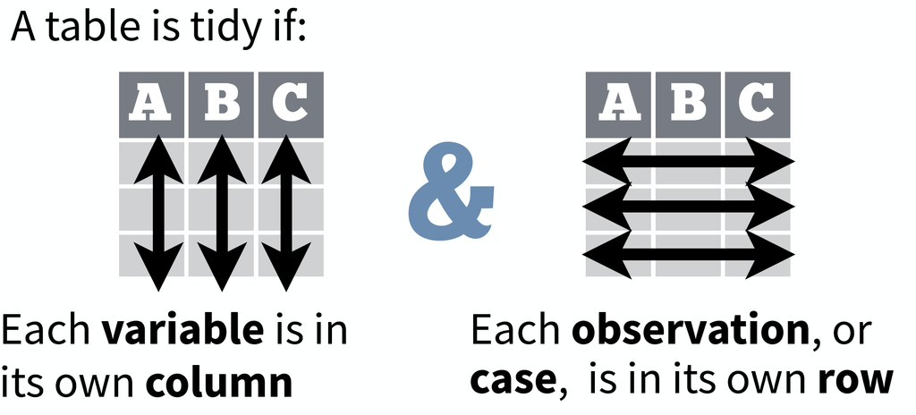

*Configuração do formato Tidy*

#### Exemplo de Funções no Tidyr

[output not shown]

### O Dplyr

O `dplyr` fornece uma gramática consistente para manipulação de dados tabulares, permitindo:

- Selecionar colunas
- Filtrar linhas com base em condições lógicas
- Ordenar os dados
- Modificar o conteúdo das variáveis
- Resumir e agregar dados

#### Exemplo de Funções no Dplyr

| Species | mean_sepal_length |
| --- | --- |
| setosa | 5.006 |
| versicolor | 5.936 |
| virginica | 6.588 |

### O GGplot2

O `ggplot2` é um pacote para visualização de dados, implementando a gramática dos gráficos. Ele permite a construção de gráficos através da combinação de camadas.

#### Exemplo de Gráfico no GGplot2

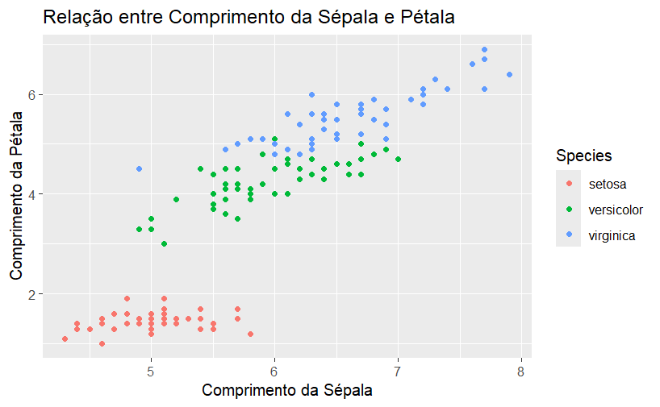

```r
# Gráfico de dispersão com ggplot2
ggplot(dados_iris, aes(x = Sepal.Length, y = Petal.Length, color = Species)) +
  geom_point() +
  labs(title = "Relação entre Comprimento da Sépala e Pétala",
       x = "Comprimento da Sépala",
       y = "Comprimento da Pétala")
```

### O Purrr

O `purrr` é um pacote para programação funcional no R. Ele facilita a aplicação de funções a listas e vetores, tornando o código mais eficiente e elegante.

#### Exemplo de Programação Funcional com Purrr

```r
medias
```

```
Sepal.Length  Sepal.Width Petal.Length  Petal.Width
    5.843333     3.057333     3.758000     1.199333
```

### O Forcats

O `forcats` facilita o trabalho com fatores, permitindo reordenar, modificar e manipular os níveis dos fatores de maneira intuitiva.

#### Exemplo de Manipulação de Fatores com Forcats

```r
# Reordenando os níveis do fator "Species" com base na frequência
dados_iris$Species <- fct_infreq(dados_iris$Species)
levels(dados_iris$Species)
```

```
[1] "setosa"     "versicolor" "virginica"
```

### O Stringr

O `stringr` simplifica operações com strings, como identificar, remover, extrair, adicionar, e manipular padrões textuais.

#### Exemplo de Operações com Strings usando Stringr

```r
# Substituindo padrões
str_replace(dados_iris$Species, "setosa", "new_species")
```

```
  [1] "new_species" "new_species" "new_species" "new_species" "new_species" "new_species" "new_species"
  [8] "new_species" "new_species" "new_species" "new_species" "new_species" "new_species" "new_species"
 [15] "new_species" "new_species" "new_species" "new_species" "new_species" "new_species" "new_species"
 [22] "new_species" "new_species" "new_species" "new_species" "new_species" "new_species" "new_species"
 [29] "new_species" "new_species" "new_species" "new_species" "new_species" "new_species" "new_species"
 [36] "new_species" "new_species" "new_species" "new_species" "new_species" "new_species" "new_species"
 [43] "new_species" "new_species" "new_species" "new_species" "new_species" "new_species" "new_species"
 [50] "new_species" "versicolor"  "versicolor"  "versicolor"  "versicolor"  "versicolor"  "versicolor"
 [57] "versicolor"  "versicolor"  "versicolor"  "versicolor"  "versicolor"  "versicolor"  "versicolor"
 [64] "versicolor"  "versicolor"  "versicolor"  "versicolor"  "versicolor"  "versicolor"  "versicolor"
 [71] "versicolor"  "versicolor"  "versicolor"  "versicolor"  "versicolor"  "versicolor"  "versicolor"
 [78] "versicolor"  "versicolor"  "versicolor"  "versicolor"  "versicolor"  "versicolor"  "versicolor"
 [85] "versicolor"  "versicolor"  "versicolor"  "versicolor"  "versicolor"  "versicolor"  "versicolor"
 [92] "versicolor"  "versicolor"  "versicolor"  "versicolor"  "versicolor"  "versicolor"  "versicolor"
 [99] "versicolor"  "versicolor"  "virginica"   "virginica"   "virginica"   "virginica"   "virginica"
[106] "virginica"   "virginica"   "virginica"   "virginica"   "virginica"   "virginica"   "virginica"
[113] "virginica"   "virginica"   "virginica"   "virginica"   "virginica"   "virginica"   "virginica"
[120] "virginica"   "virginica"   "virginica"   "virginica"   "virginica"   "virginica"   "virginica"
[127] "virginica"   "virginica"   "virginica"   "virginica"   "virginica"   "virginica"   "virginica"
[134] "virginica"   "virginica"   "virginica"   "virginica"   "virginica"   "virginica"   "virginica"
[141] "virginica"   "virginica"   "virginica"   "virginica"   "virginica"   "virginica"   "virginica"
[148] "virginica"   "virginica"   "virginica"
```

### O Lubridate e HMS

Os pacotes `lubridate` e `hms` facilitam a manipulação de datas, horas e durações no R, permitindo trabalhar de forma intuitiva com dados cronológicos.

#### Exemplo de Manipulação de Datas com Lubridate e HMS

```r
horario
```

```
12:34:56
```

### O Magrittr e o Operador Pipe

O pacote `magrittr` fornece o operador pipe `%>%`, que permite encadear operações de maneira clara e sequencial.

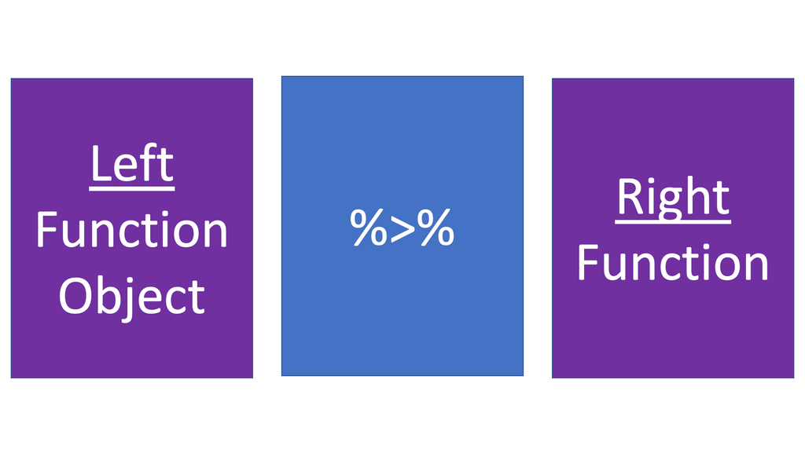

*Configuração do Operador Pipe*

#### Exemplo de Uso do Pipe

| Sepal.Length | Sepal.Width | Sepal.Ratio |
| --- | --- | --- |
| 5.1 | 3.5 | 1.457143 |
| 4.9 | 3.0 | 1.633333 |
| 4.7 | 3.2 | 1.468750 |
| 4.6 | 3.1 | 1.483871 |
| 5.0 | 3.6 | 1.388889 |
| 5.4 | 3.9 | 1.384615 |
| 4.6 | 3.4 | 1.352941 |
| 5.0 | 3.4 | 1.470588 |
| 4.4 | 2.9 | 1.517241 |
| 4.9 | 3.1 | 1.580645 |

[output cut: 40 more lines]

## Conclusão

Nesta aula, exploramos os principais pacotes do Tidyverse, que são fundamentais para manipulação e visualização de dados no R

. Combinando o poder desses pacotes, você pode realizar tarefas complexas de maneira eficiente e organizada, garantindo que seus projetos de ciência de dados sejam bem-sucedidos.

Na próxima aula, vamos aprofundar o uso do Tidyverse, explorando técnicas avançadas de manipulação e visualização de dados.